# Climate Change Data Analysis

2023-03-24

#Time is passing! Climate change will have and already has profound effects on our lives if we don’t take a step. It will seriously impact the diversity in the world. We need to act now!

#I’ll be investigating historical temperature data in this project to better understand the trends and patterns of climate change in the UK. This project aims at conducting a data analysis on climate change by creating data visualisations.

#DATASET #The dataset we’ll be working with includes monthly average temperatures from 1884 through 2022, as well as seasonal and annual averages. #We will obtain insights into how temperatures have changed throughout time and find any notable trends that may be indicative of climate change by studying this data. #We’ll start by loading the dataset into R and doing some exploratory data analysis.

#Cleaning and formatting the data, as well as computing summary statistics to better understand the temperature distribution across time, are all part of this process.

#We will also create graphics to help detect any patterns or trends in the data. #Then, we’ll dig deeper into the data by looking at annual average temperature trends. #We’ll use techniques like linear regression and moving averages to uncover long-term trends in temperature rises.

#We’ll look at seasonal temperature patterns in addition to annual trends. #We may investigate how climate change may be altering weather patterns throughout the year by splitting down the data by season. #This data is critical for comprehending the possible impacts of climate change on agriculture, water resources, and ecosystems.

#Lastly, we’ll bring the research to a close by presenting our findings in a clear and visually appealing manner. #We’ll produce well-designed plots and charts to effectively communicate our findings and help potential recruiters understand the important insights from our investigation.

#LOADING PACKAGES

```r
library(tidyverse)   # for data wrangling
```

```r
library(lubridate)   # for working with dates
library(ggplot2)     # for plotting
library(ggthemes)    # for more plotting options
library(gridExtra)   # for arranging plots
library(readxl)
library(dplyr)
```

#LOADING DATASET

```r
# Load the dataset
temperature <- read_xlsx("mean_temp_UK.xlsx")
```

#DATA EXPLORATION

```r
# Examine the first few rows of the dataset
head(temperature)
```

```
## # A tibble: 6 × 18
##    year   jan   feb   mar   apr   may   jun   jul   aug   sep   oct   nov   dec
##   <dbl> <dbl> <dbl> <dbl> <dbl> <dbl> <dbl> <dbl> <dbl> <dbl> <dbl> <dbl> <dbl>
## 1  1884   5     4.2   5.1   6.2   9.7  12.5  14.5  15.3  13     8.3   4.6   3.3
## 2  1885   2     4.2   3.5   6.6   7.6  12.3  14.5  12.4  10.9   6.2   4.8   3
## 3  1886   1.1   0.8   2.9   6.3   8.8  11.9  14.2  14.1  12     9.9   5.7   1.2
## 4  1887   2.1   3.5   3.3   5.4   8.7  14.3  15.6  14    10.6   6.4   3.9   2.1
## 5  1888   2.8   1.1   2.1   5.3   9.2  11.8  12.3  12.8  11.2   7.6   6.5   4.3
## 6  1889   3     2.2   3.8   6    11.4  14    13.6  13.4  11.5   7.6   6.1   3.1
## # ℹ 5 more variables: win <dbl>, spr <dbl>, sum <dbl>, aut <dbl>, ann <dbl>
```

```r
# Check the dimensions of the dataset
dim(temperature) #The dataset contains 139 years of temperature data
```

```
## [1] 139  18
```

```r
# Get the summary statistics for each variable
summary(temperature)
```

```
##       year           jan              feb              mar
##  Min.   :1884   Min.   :-1.900   Min.   :-2.300   Min.   :1.800
##  1st Qu.:1918   1st Qu.: 2.400   1st Qu.: 2.400   1st Qu.:3.900
##  Median :1953   Median : 3.400   Median : 3.700   Median :5.100
##  Mean   :1953   Mean   : 3.189   Mean   : 3.324   Mean   :4.848
##  3rd Qu.:1988   3rd Qu.: 4.200   3rd Qu.: 4.450   3rd Qu.:5.800
##  Max.   :2022   Max.   : 6.300   Max.   : 6.800   Max.   :8.000
##       apr              may              jun             jul
##  Min.   : 4.300   Min.   : 7.500   Min.   :10.50   Min.   :12.30
##  1st Qu.: 6.300   1st Qu.: 9.300   1st Qu.:12.30   1st Qu.:13.90
##  Median : 7.000   Median : 9.900   Median :12.80   Median :14.50
##  Mean   : 7.022   Mean   : 9.991   Mean   :12.85   Mean   :14.62
##  3rd Qu.: 7.900   3rd Qu.:10.750   3rd Qu.:13.40   3rd Qu.:15.30
##  Max.   :10.700   Max.   :12.100   Max.   :14.90   Max.   :17.80
##       aug             sep             oct              nov
##  Min.   :11.70   Min.   : 9.90   Min.   : 5.900   Min.   :2.300
##  1st Qu.:13.70   1st Qu.:11.70   1st Qu.: 8.300   1st Qu.:5.000
##  Median :14.30   Median :12.40   Median : 9.200   Median :5.700
##  Mean   :14.39   Mean   :12.33   Mean   : 9.119   Mean   :5.747
##  3rd Qu.:15.10   3rd Qu.:13.00   3rd Qu.: 9.800   3rd Qu.:6.600
##  Max.   :17.30   Max.   :15.20   Max.   :12.200   Max.   :8.800
##       dec             win              spr             sum
##  Min.   :-0.90   Min.   :-0.290   Min.   :5.420   Min.   :12.23
##  1st Qu.: 3.00   1st Qu.: 2.755   1st Qu.:6.700   1st Qu.:13.39
##  Median : 3.90   Median : 3.520   Median :7.160   Median :13.99
##  Mean   : 3.84   Mean   : 3.459   Mean   :7.289   Mean   :13.97
##  3rd Qu.: 4.80   3rd Qu.: 4.260   3rd Qu.:7.870   3rd Qu.:14.42
##  Max.   : 7.90   Max.   : 5.790   Max.   :9.120   Max.   :15.76
##       aut              ann
##  Min.   : 6.970   Min.   : 7.020
##  1st Qu.: 8.595   1st Qu.: 8.075
##  Median : 9.100   Median : 8.350
##  Mean   : 9.067   Mean   : 8.468
##  3rd Qu.: 9.670   3rd Qu.: 8.855
##  Max.   :11.350   Max.   :10.030
```

```r
# Check for missing values
colSums(is.na(temperature))
```

```
## year  jan  feb  mar  apr  may  jun  jul  aug  sep  oct  nov  dec  win  spr  sum
##    0    0    0    0    0    0    0    0    0    0    0    0    0    0    0    0
##  aut  ann
##    0    0
```

```r
# Calculate the seasonal averages
temperature_v2 <- temperature %>%
  mutate(winter_avg = round(apply(select(., jan, feb, dec), 1, mean, na.rm = TRUE), 2),
         spring_avg = round(apply(select(., mar, apr, may), 1, mean, na.rm = TRUE), 2),
         summer_avg = round(apply(select(., jun, jul, aug), 1, mean, na.rm = TRUE), 2),
         autumn_avg = round(apply(select(., sep, oct, nov), 1, mean, na.rm = TRUE), 2))
```

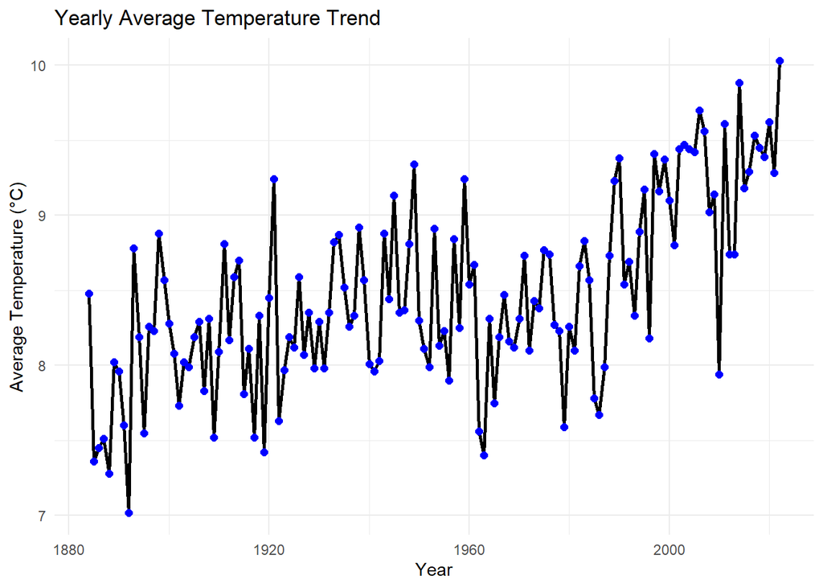

```r
# Compute the average temperature for each year
yearly_avg <- temperature_v2 %>%
  select(year, ann)

# Create a line plot to visualize the trend of average temperature over time
ggplot(yearly_avg, aes(x = year, y = ann)) +
  geom_line(color = "black", size = 1) +
  geom_point(color = "blue", size = 2) +
  theme_minimal() +
  labs(title = "Yearly Average Temperature Trend",
       x = "Year",
       y = "Average Temperature (°C)")
```

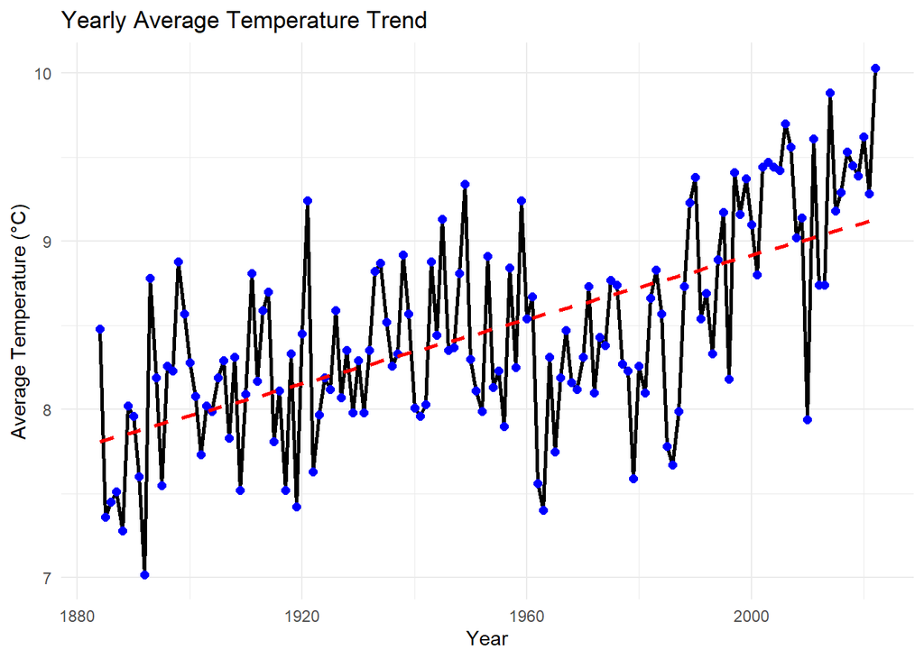

```r
# Create a line plot to visualize the trend of average temperature over time, with a trend line
ggplot(yearly_avg, aes(x = year, y = ann)) +
  geom_line(color = "black", size = 1) +
  geom_point(color = "blue", size = 2) +
  geom_smooth(method = "lm", se = FALSE, color = "red", linetype = "dashed") +
  theme_minimal() +
  labs(title = "Yearly Average Temperature Trend",
       x = "Year",
       y = "Average Temperature (°C)")
```

#The line plot illustrates the increasing level of global warming.

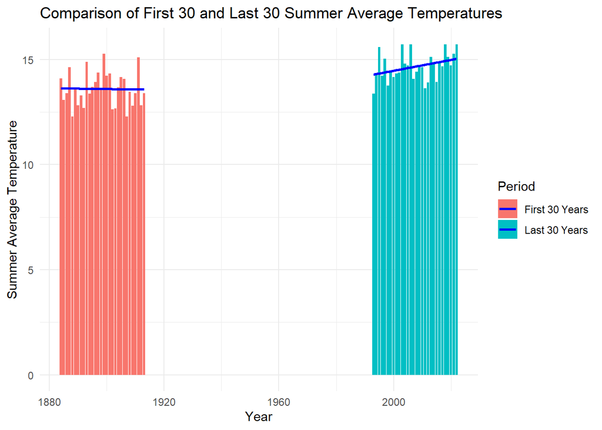

```r
# Filter first 20 and last 20 summer average values
first_30_summer <- temperature_v2 %>%
  head(30) %>%
  select(year, summer_avg)

last_30_summer <- temperature_v2 %>%
  tail(30) %>%
  select(year, summer_avg)

# Combine the first 20 and last 20 summer average values
summer_comparison <- rbind(first_30_summer %>%
                             mutate(period = "First 30 Years"),
                           last_30_summer %>%
                             mutate(period = "Last 30 Years"))

# Create a bar plot to visualize the comparison and add a linear regression line
ggplot(summer_comparison, aes(x = year, y = summer_avg, fill = period)) +
  geom_bar(stat = "identity", position = "dodge") +
  geom_smooth(method = "lm", se = FALSE, color = "blue", linetype = "solid") +
  theme_minimal() +
  labs(title = "Comparison of First 30 and Last 30 Summer Average Temperatures",
       x = "Year",
       y = "Summer Average Temperature",
       fill = "Period")
```

#The regression line indicates a rising trend in the last 30 years, in contrast to the first 30-year period, which displayed a more linear progression. Furthermore, a significant increase in temperature levels is also evident.

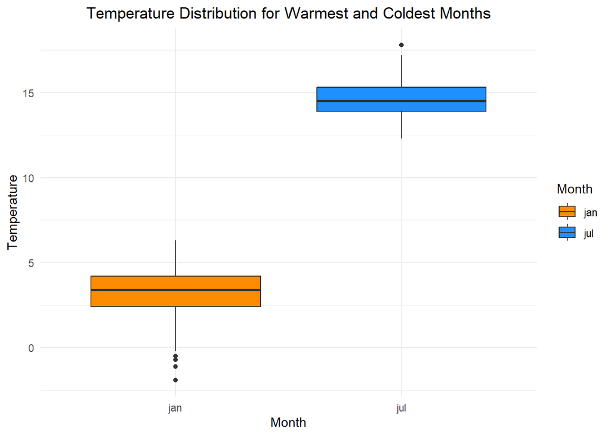

```r
# Reshape the data to a long format with only monthly temperature columns
monthly_data_long <- temperature_v2 %>%
  select(year, jan:dec) %>%
  gather(month, temperature, -year)

# Calculate the overall average temperature for each month
monthly_averages <- monthly_data_long %>%
  group_by(month) %>%
  summarise(average_temp = mean(temperature, na.rm = TRUE))

# Identify the warmest and coldest months
warmest_month <- monthly_averages[which.max(monthly_averages$average_temp), "month"]
coldest_month <- monthly_averages[which.min(monthly_averages$average_temp), "month"]

# Filter the data to include only the warmest and coldest months
warmest_coldest_data <- monthly_data_long %>%
  filter(month %in% c(warmest_month, coldest_month))

# Create box plots for the warmest and coldest months
ggplot(warmest_coldest_data, aes(x = month, y = temperature, fill = month)) +
  geom_boxplot() +
  theme_minimal() +
  labs(title = "Temperature Distribution for Warmest and Coldest Months",
       x = "Month",
       y = "Temperature",
       fill = "Month") +
  theme(plot.title = element_text(hjust = 0.5)) +
  scale_fill_manual(values = c("darkorange", "dodgerblue"))
```

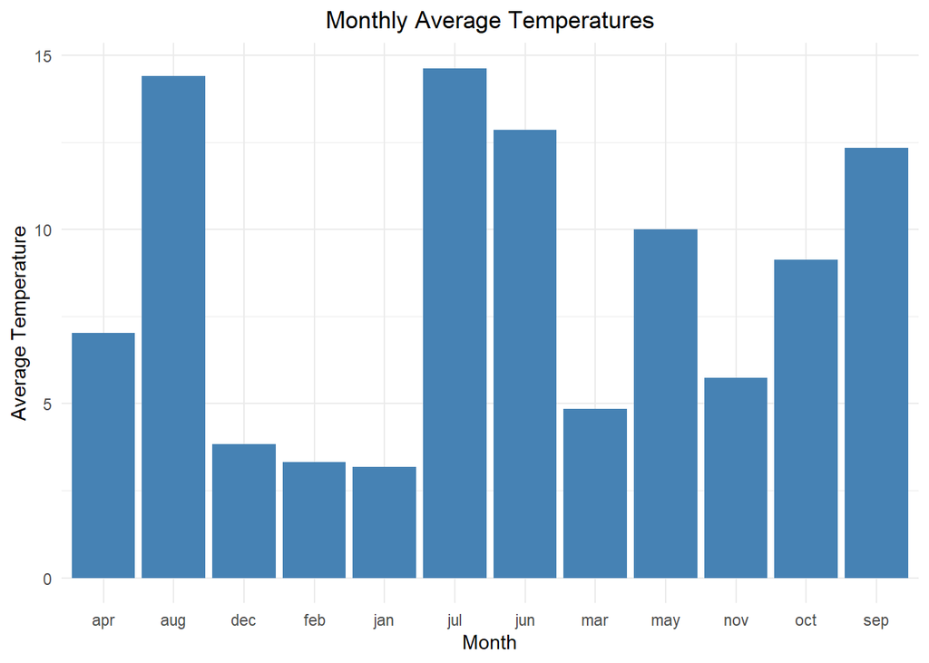

```r
# Calculate monthly averages
monthly_avg <- colMeans(temperature_v2[, c("jan", "feb", "mar", "apr", "may", "jun", "jul", "aug", "sep", "oct", "nov", "dec")], na.rm = TRUE)

# Create a data frame for plotting
monthly_avg_df <- data.frame(month = names(monthly_avg), average = monthly_avg)

# Bar plot for monthly averages
ggplot(monthly_avg_df, aes(x = month, y = average)) +
  geom_bar(stat = "identity", fill = "steelblue") +
  theme_minimal() +
  labs(title = "Monthly Average Temperatures", x = "Month", y = "Average Temperature") +
  theme(plot.title = element_text(hjust = 0.5))
```

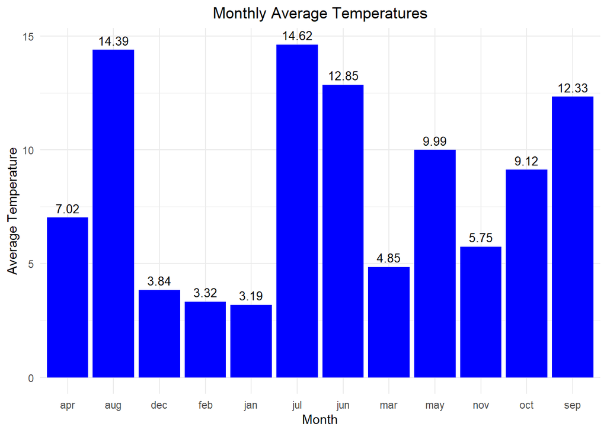

```r
# Bar plot for monthly averages with values
ggplot(monthly_avg_df, aes(x = month, y = average)) +
  geom_bar(stat = "identity", fill = "blue") +
  geom_text(aes(label = round(average, 2)), vjust = -0.5, size = 3.5) +
  theme_minimal() +
  labs(title = "Monthly Average Temperatures", x = "Month", y = "Average Temperature") +
  theme(plot.title = element_text(hjust = 0.5))
```

[figure not shown]

```r
# Plot the annual average temperatures
ggplot(temperature, aes(x = year, y = ann)) +
  geom_line() +
  geom_smooth(method = "lm", se = FALSE, color = "red") +
  labs(title = "Annual Average Temperatures (1884-2021)",
       x = "Year",
       y = "Temperature (°C)") +
  theme_minimal()
```

#CALCULATING SEASONAL AVERAGES

```r
# Select the specified columns from the temperature dataset
seasonal_data <- temperature %>%
  select(year, win, spr, sum, aut, ann)

# Rename the columns
seasonal_data <- seasonal_data %>%
  rename(winter = win,
         spring = spr,
         summer = sum,
         autumn = aut,
         annual = ann)

# Merge the seasonal data with the original dataset
temperature_v2 <- left_join(temperature_v2, seasonal_data, by = "year")
```

```r
# Create a dataset with average temperature for each month
monthly_avg <- temperature_v2 %>%
  summarise_at(vars(jan:dec), mean, na.rm = TRUE) %>%
  gather(key = "month", value = "temperature") %>%
  mutate(month = factor(month, levels = c("jan", "feb", "mar", "apr", "may", "jun", "jul", "aug", "sep", "oct", "nov", "dec")))

# Create a season variable
monthly_avg$season <- case_when(
  monthly_avg$month %in% c("dec", "jan", "feb") ~ "winter",
  monthly_avg$month %in% c("mar", "apr", "may") ~ "spring",
  monthly_avg$month %in% c("jun", "jul", "aug") ~ "summer",
  monthly_avg$month %in% c("sep", "oct", "nov") ~ "autumn"
)

# Preview the dataset
head(monthly_avg)
```

```
## # A tibble: 6 × 3
##   month temperature season
##   <fct>       <dbl> <chr>
## 1 jan          3.19 winter
## 2 feb          3.32 winter
## 3 mar          4.85 spring
## 4 apr          7.02 spring
## 5 may          9.99 spring
## 6 jun         12.9  summer
```

```r
# Calculate seasonal averages for each year
seasonal_avg_by_year <- temperature_v2 %>%
  gather(key = "season", value = "temperature", c("winter_avg", "spring_avg", "summer_avg", "autumn_avg")) %>%
  group_by(year, season) %>%
  summarise(avg_temperature = mean(temperature, na.rm = TRUE))
```

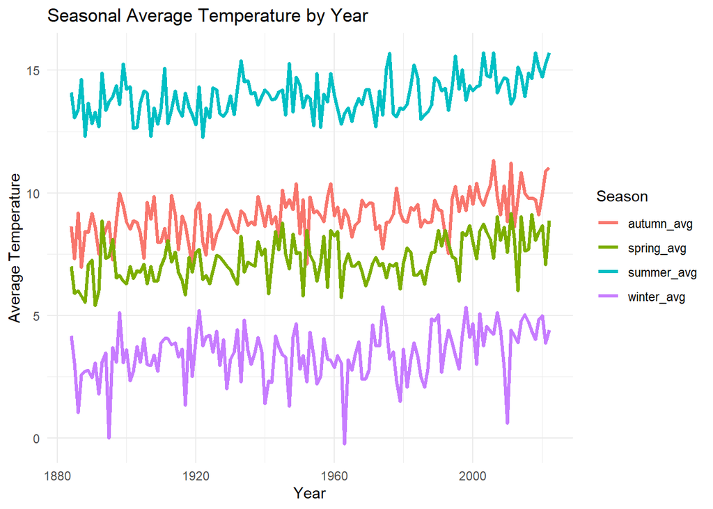

```r
# Create a line plot to visualize seasonal averages by year
ggplot(seasonal_avg_by_year, aes(x = year, y = avg_temperature, color = season, group = season)) +
  geom_line(size = 1.1) +
  theme_minimal() +
  labs(title = "Seasonal Average Temperature by Year",
       x = "Year",
       y = "Average Temperature",
       color = "Season")
```

#For each season, an upward trend in the seasonal average can be observed.

#Moving Average

```r
# Load the zoo package
#install.packages("zoo")
library(zoo)
```

[figure not shown]

```r
# Calculate moving averages
temperature_v2$ma_5_year <- rollmean(temperature_v2$annual, k = 5, fill = NA, align = "right")
temperature_v2$ma_10_year <- rollmean(temperature_v2$annual, k = 10, fill = NA, align = "right")

# Reshape the data to a long format
moving_avg_long <- temperature_v2 %>%
  select(year, ma_5_year, ma_10_year) %>%
  gather(key = "moving_avg", value = "temperature", c("ma_5_year", "ma_10_year"))

# Create a line plot to visualize moving averages
ggplot(moving_avg_long, aes(x = year, y = temperature, color = moving_avg, group = moving_avg)) +
  geom_line(size = 1) +
  theme_minimal() +
  labs(title = "Moving Averages of Annual Average Temperatures",
       x = "Year",
       y = "Average Temperature",
       color = "Moving Average") +
  scale_color_discrete(labels = c("5-Year", "10-Year"))
```

#HIGHEST AND LOWEST AVERAGE TEMPERATURES

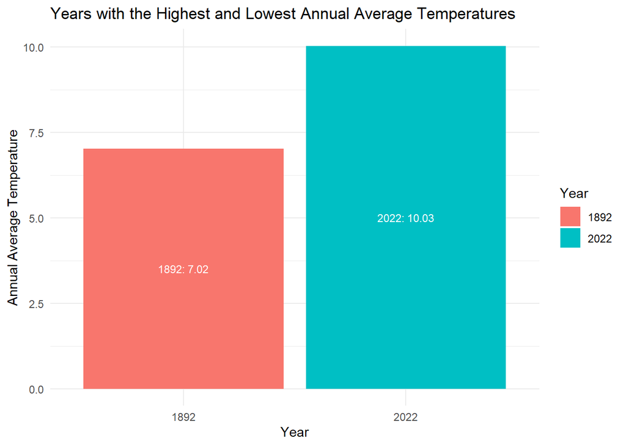

```r
# Identify the years with the highest and lowest annual average temperatures
max_year <- temperature_v2[which.max(temperature_v2$ann), c("year", "ann")]
min_year <- temperature_v2[which.min(temperature_v2$ann), c("year", "ann")]

# Create a bar plot to visualize the highest and lowest annual average temperatures
ggplot(rbind(max_year, min_year), aes(x = factor(year), y = ann, fill = factor(year))) +
  geom_bar(stat = "identity") +
  theme_minimal() +
  labs(title = "Years with the Highest and Lowest Annual Average Temperatures",
       x = "Year",
       y = "Annual Average Temperature",
       fill = "Year") +
  scale_fill_discrete(name = "Year") +
  geom_text(aes(label = paste(year, ann, sep = ": ")),
            position = position_stack(vjust = 0.5),
            color = "white", size = 3)
```